# What My Bank Balance Knows About Me 💸

## The Question 🔍

I started tracking my spending because I wanted to understand something I could not see just from my bank balance: **is my spending actually random, or does it follow patterns I do not notice?**

At the time, it felt like my money was disappearing without much explanation. One minute I had money, and the next it was gone. So I decided to stop guessing and track it properly. Over time, I logged **71 purchases** using a Google Form, recording what I bought, whether it was a need or want, my mood at the time, and the time of day.

This visual story explores the patterns behind my spending, including what I buy, when I spend, and how my mood influences those decisions.

## What am I spending most on?💰

Most people assume their biggest spending would be on bills or essentials, but my data says otherwise…

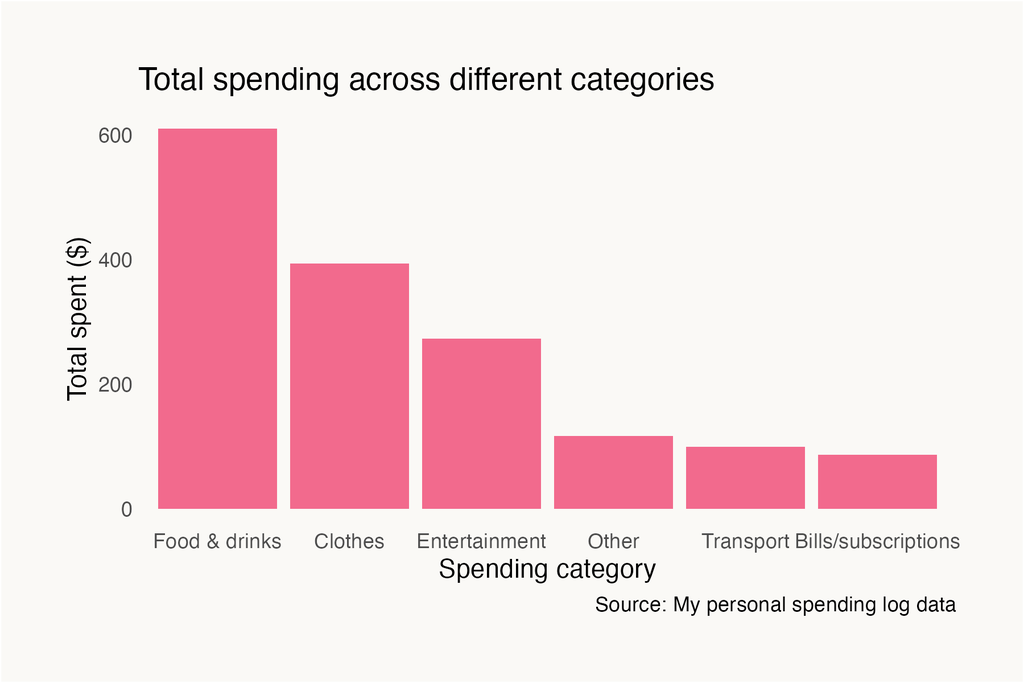

*My budget is being held hostage by iced coffees.*

Most of my spending is concentrated in a few key categories rather than being evenly spread out. **Food and drinks make up the largest portion of my spending**, followed by clothes and entertainment. Smaller categories like transport and bill/subscriptions make up much less overall.

This suggests that my spending is less about unavoidable costs, and more about lifestyle spending - the kind of purchases that feel small in the moment but add up fast.

## Does my mood affect how I spend? 😁🥱😰😐

This is where the data stops feeling like numbers and starts feeling a bit too honest.

*These are the moods I logged while spending…*

[figure not shown]

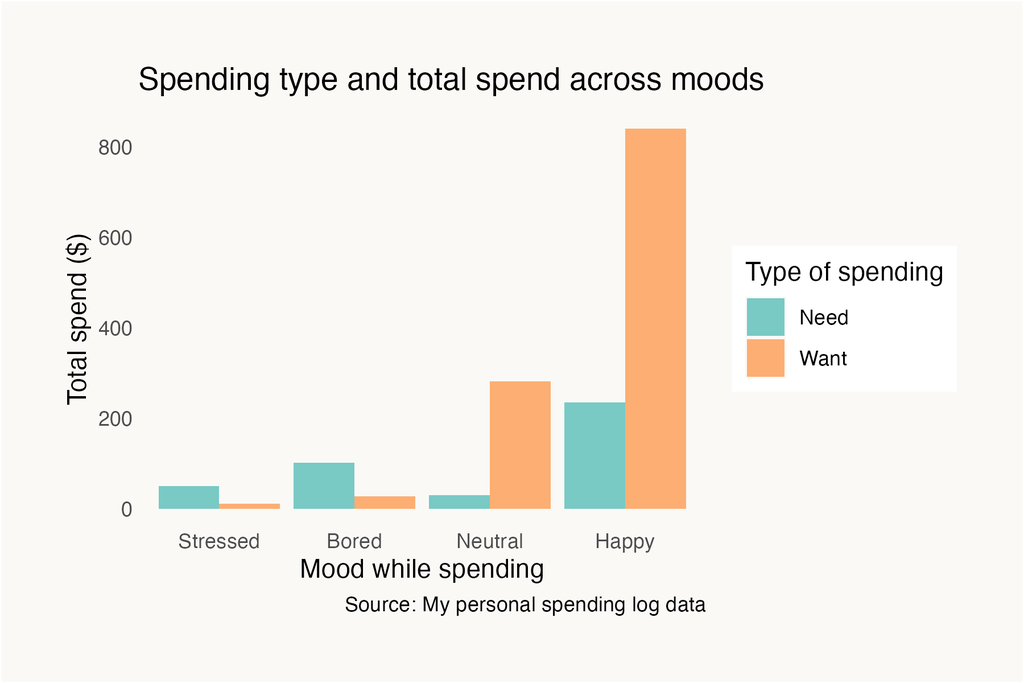

*Happiness is expensive. Noted.*

**I tend to spend the most when I’m feeling happy**, especially on “want” purchases rather than “needs”. This suggests that being in a good mood does not help me save money. Instead, it makes me more likely to spend.

When I’m bored or stressed, spending shifts more toward needs, which feels more practical and less impulsive.

So mood does not just change how much I spend. It also changes what I spend my money on.

[figure not shown]

## When do I spend the most money during the day? 🤔

I expected spending to be spread evenly across the day… but apparently my wallet has a favourite time to suffer.

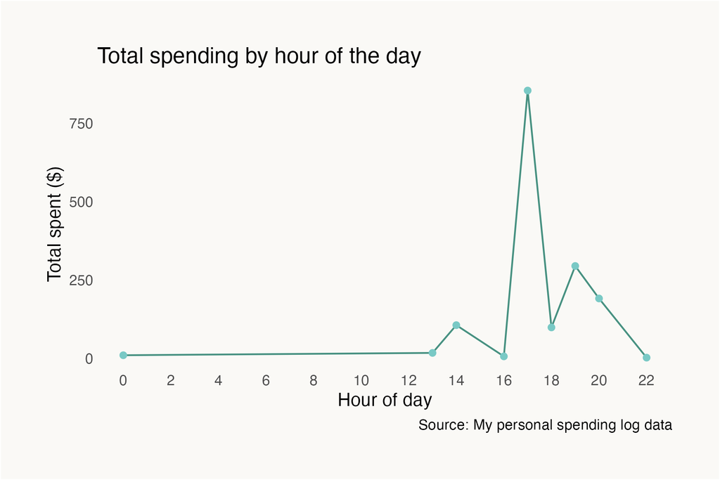

*My wallet should probably log off at 5pm.*

**There is a clear spike around 5pm, where my spending is highest**. This usually lines up with finishing my day, feeling tired, and being more likely to scroll or buy something without thinking too much.

Overall, **my spending seems to cluster in periods where I’m less busy and more relaxed**.

## Do I usually make small or large purchases 🛍️

Finally, I wanted to see whether my spending problem comes from big dramatic purchases…or something sneakier.

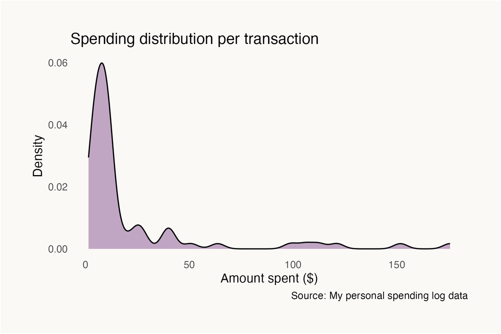

*It’s not the big purchases… it’s the little ones that sneak attack*

**Most of my transactions are small everyday purchases**, with only a few larger spending events. This creates a pattern where frequent low-value purchases dominate my spending behaviour, while large purchases stand out as occasional spikes.

So instead of big dramatic spending moments, it’s many small decisions that add up quietly.

## Final takeaway 🎬

One thing is clear: **my spending is not random, even though it *feels* like it.**

Most of my money goes toward lifestyle spending like food and clothes rather than essentials. Spending also peaks later in the day, and mood clearly affects whether I make want or need purchases.

My spending personality:

- 🍔 **Biggest weakness**: food and drinks
- 😄 **Most expensive mood**: happy
- ⏰ **Most dangerous time**: ~5pm
- 💸 **Spending style**: death by small purchases

Overall, my spending is not chaotic. It is just quietly consistent in ways I do not always notice.